# MPDW Pertemuan 7

Febri Dwi Cahyanto G1401211049

2023-10-16

###library

```r
library("forecast")
```

```r
library("graphics")
library("TTR")
library("TSA")
library(dplyr)
library(forecast)
library(lmtest)
library(orcutt)
library(HoRM)
library(corrplot)
library(dLagM)
library(dynlm)
library(MLmetrics)
library(ggplot2)
library(tsibble)
library(tseries)
library(MASS)
library(aTSA)
```

### Input data

```r
library(readxl)
datakukd <- read_excel("C:/Users/user/Downloads/mpdw11.xlsx")
datakukd
```

```
## # A tibble: 132 × 2
##    bulan  suhu
##    <dbl> <dbl>
##  1     1  26.1
##  2     2  26.6
##  3     3  26.7
##  4     4  26.5
##  5     5  26.1
##  6     6  25.4
##  7     7  25
##  8     8  25.2
##  9     9  26.0
## 10    10  26.0
## # ℹ 122 more rows
```

### Ubah data menjadi time series

```r
datakukd.ts <- ts(datakukd$suhu)
```

### Membagi data menjadi data latih (80%) dan data uji (20%) dan jadikan time series

```r
dtkukd.latih <- datakukd[1:106,2]
dtkukd.uji <- datakukd[107:132,2]
dtkukd.latih.ts <- ts(dtkukd.latih, frequency = 12)
dtkukd.uji.ts <- ts(dtkukd.uji, frequency = 12)
```

### Eksplorasi data

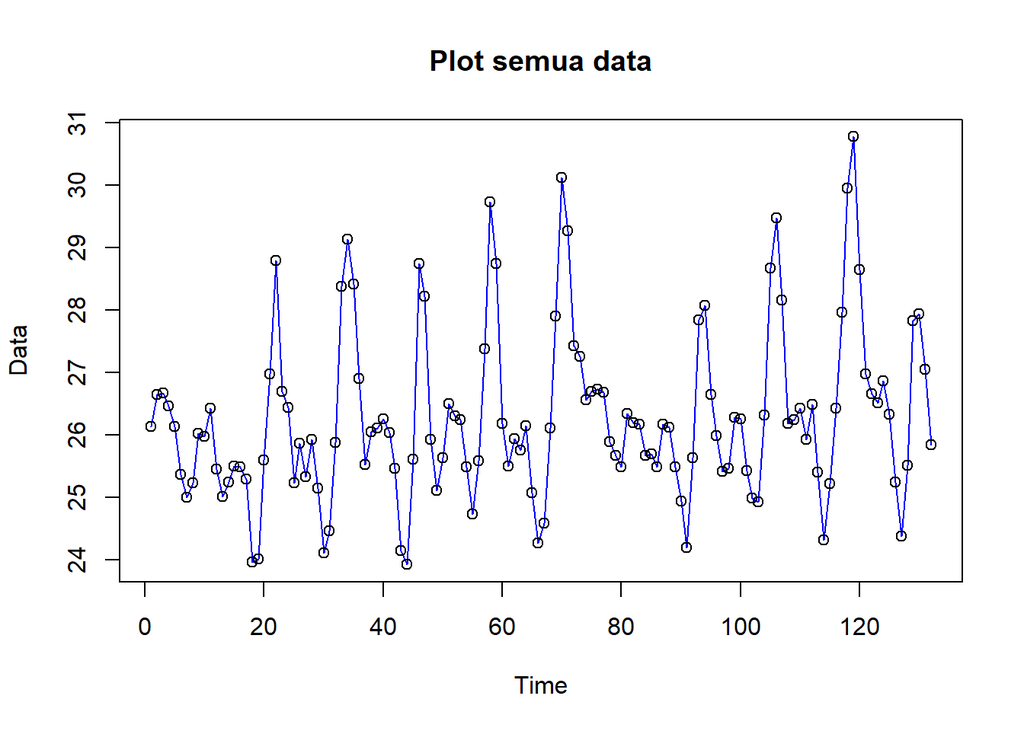

```r
# data full
ts.plot(datakukd.ts, col="blue",main="Plot semua data", type="o",xlab="Time",ylab="Data")
points(datakukd.ts)
```

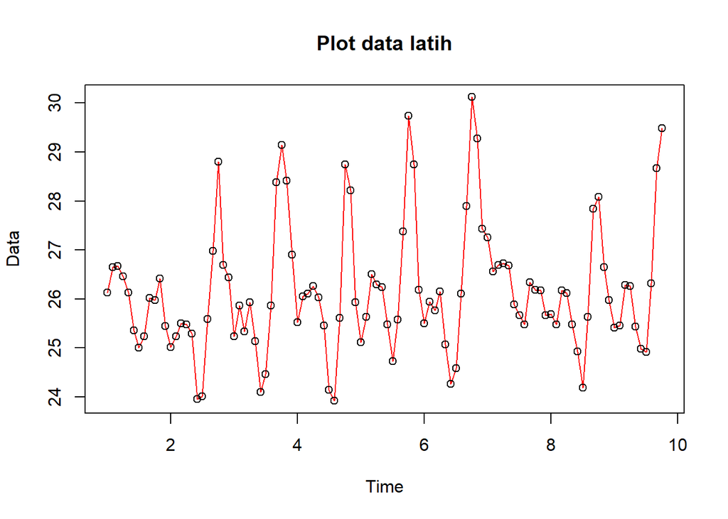

```r
# data latih
ts.plot(dtkukd.latih.ts, col="red",main="Plot data latih", type="o",xlab="Time",ylab="Data")
points(dtkukd.latih.ts)
```

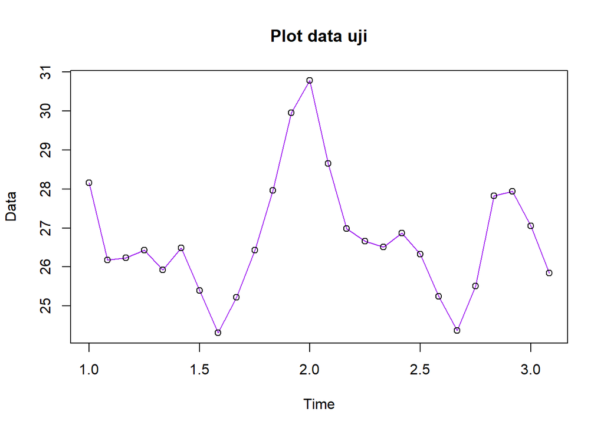

```r
# data uji
ts.plot(dtkukd.uji.ts, col="purple",main="Plot data uji", type="o",xlab="Time",ylab="Data")
points(dtkukd.uji.ts)
```

## CEK Stasioner

### Plot acf

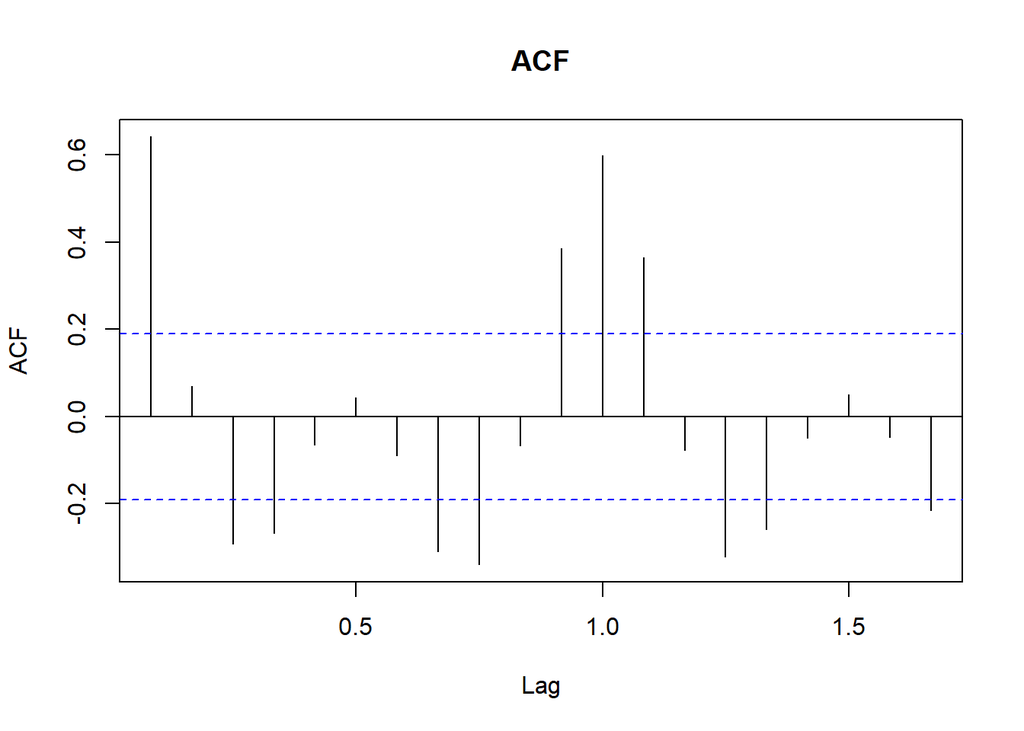

```r
acf(dtkukd.latih.ts, main="ACF", lag.max=20)
```

Berdasarkan plot ACF, terlihat bahwa plot ACF pada data tersebut cenderung *cut off* dan membentuk gelombang sinus. menandakan bahwa data tersebut stasioner dalam rataan

### Uji ADF

```r
tseries::adf.test(dtkukd.latih.ts)
```

```
##
##  Augmented Dickey-Fuller Test
##
## data:  dtkukd.latih.ts
## Dickey-Fuller = -4.4161, Lag order = 4, p-value = 0.01
## alternative hypothesis: stationary
```

$H_0$ : Data tidak stasioner dalam rataan

$H_1$ : Data stasioner dalam rataan

Berdasarkan uji ADF tersebut, didapat *p-value* sebesar 0.01 yang lebih kecil dari taraf nyata 5% sehingga tolak $H_0$ dan menandakan bahwa data stasioner dalam rataan. Hal ini sesuai dengan hasil eksplorasi menggunakan plot time series dan plot ACF.

### Plot Box-Cox

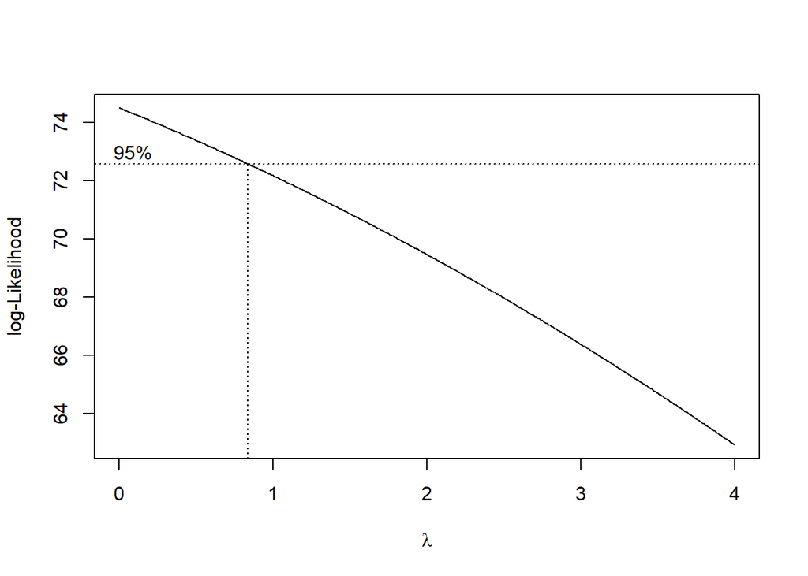

```r
index <- seq(1:106)
bc = boxcox(dtkukd.latih.ts~index, lambda = seq(0,4,by=0.01))
```

```r
#Nilai Rounded Lambda
lambda <- bc$x[which.max(bc$y)]
lambda
```

```
## [1] 0
```

```r
#SK
bc$x[bc$y > max(bc$y) - 1/2 * qchisq(.95,1)]
```

```
##  [1] 0.00 0.01 0.02 0.03 0.04 0.05 0.06 0.07 0.08 0.09 0.10 0.11 0.12 0.13 0.14
## [16] 0.15 0.16 0.17 0.18 0.19 0.20 0.21 0.22 0.23 0.24 0.25 0.26 0.27 0.28 0.29
## [31] 0.30 0.31 0.32 0.33 0.34 0.35 0.36 0.37 0.38 0.39 0.40 0.41 0.42 0.43 0.44
## [46] 0.45 0.46 0.47 0.48 0.49 0.50 0.51 0.52 0.53 0.54 0.55 0.56 0.57 0.58 0.59
## [61] 0.60 0.61 0.62 0.63 0.64 0.65 0.66 0.67 0.68 0.69 0.70 0.71 0.72 0.73 0.74
## [76] 0.75 0.76 0.77 0.78 0.79 0.80 0.81 0.82 0.83
```

Gambar di atas menunjukkan nilai *rounded value* ($\lambda$) optimum sebesar **0** dan pada selang kepercayaan 95% nilai memiliki batas bawah **0.00** dan batas atas **0.83**. Selang tersebut tidak memuat nilai satu sehingga dapat dikatakan bahwa data tidak stasioner dalam ragam.

## Identifikasi model

### Plot ACF dan PACF

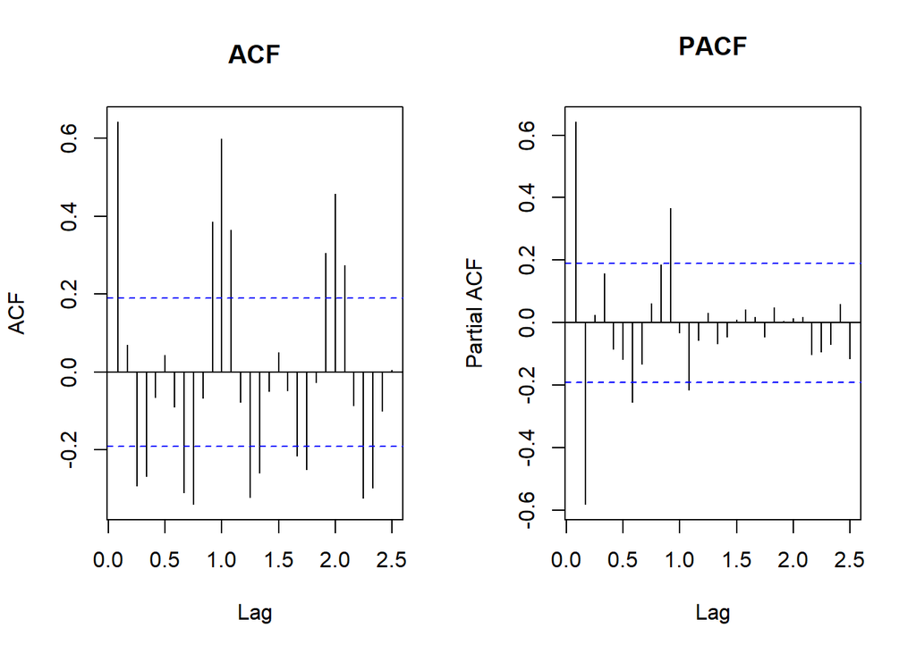

```r
par(mfrow = c(1,2))
acf(dtkukd.latih.ts, main="ACF", lag.max=30) #ARIMA(0,0,1)
pacf(dtkukd.latih.ts, main="PACF", lag.max=30) #ARIMA(2,0,0)
```

### Plot EACF

```r
eacf(dtkukd.latih.ts)
```

```
## AR/MA
##   0 1 2 3 4 5 6 7 8 9 10 11 12 13
## 0 x o x x o o o x x o x  x  x  o
## 1 x o x x o o o x x o x  x  x  o
## 2 o x o o o o o o o o o  x  o  o
## 3 x x o o x o o o o o o  o  o  o
## 4 x x o o o o o o o o o  o  o  o
## 5 x o x o o o o o o o o  o  o  o
## 6 x o x x o o o o o x o  o  o  x
## 7 x x o x o o o o o o o  o  o  x
```

identifikasi model menggunakan plot EACF dilakukan dengan melihat ujung segitiga pada pola segitiga nol. Dalam hal ini model tentatif yang terbentuk adalah ARIMA (2,0,2), dan ARIMA (2,0,3)

## Pendugaan Parameter

### ARIMA (0,0,1)

```r
model1=Arima(dtkukd.latih.ts, order=c(0,0,1),method="ML")
summary(model1) #AIC=292.16
```

```
## Series: dtkukd.latih.ts
## ARIMA(0,0,1) with non-zero mean
##
## Coefficients:
##          ma1     mean
##       0.7212  26.1787
## s.e.  0.0523   0.1549
##
## sigma^2 = 0.8815:  log likelihood = -143.08
## AIC=292.16   AICc=292.4   BIC=300.15
##
## Training set error measures:
##                        ME      RMSE       MAE        MPE     MAPE      MASE
## Training set 0.0005261159 0.9299888 0.7139989 -0.1464031 2.699869 0.8386342
##                   ACF1
## Training set 0.3091157
```

```r
lmtest::coeftest(model1)
```

```
##
## z test of coefficients:
##
##           Estimate Std. Error z value  Pr(>|z|)
## ma1        0.72121    0.05229  13.793 < 2.2e-16 ***
## intercept 26.17872    0.15487 169.042 < 2.2e-16 ***
## ---
## Signif. codes:  0 '***' 0.001 '**' 0.01 '*' 0.05 '.' 0.1 ' ' 1
```

### ARIMA (2,0,0)

```r
model2=Arima(dtkukd.latih.ts, order=c(2,0,0),method="ML")
summary(model2) #AIC=252.61
```

```
## Series: dtkukd.latih.ts
## ARIMA(2,0,0) with non-zero mean
##
## Coefficients:
##          ar1      ar2     mean
##       1.0813  -0.6304  26.1601
## s.e.  0.0764   0.0770   0.1352
##
## sigma^2 = 0.5966:  log likelihood = -122.3
## AIC=252.61   AICc=253   BIC=263.26
##
## Training set error measures:
##                       ME      RMSE       MAE         MPE     MAPE      MASE
## Training set 0.001966055 0.7613641 0.6020348 -0.07573864 2.286401 0.7071257
##                  ACF1
## Training set 0.036273
```

```r
lmtest::coeftest(model2)
```

```
##
## z test of coefficients:
##
##            Estimate Std. Error  z value  Pr(>|z|)
## ar1        1.081325   0.076391  14.1552 < 2.2e-16 ***
## ar2       -0.630380   0.077033  -8.1833 2.762e-16 ***
## intercept 26.160073   0.135229 193.4497 < 2.2e-16 ***
## ---
## Signif. codes:  0 '***' 0.001 '**' 0.01 '*' 0.05 '.' 0.1 ' ' 1
```

### ARIMA (2,0,2)

```r
model3=Arima(dtkukd.latih.ts, order=c(2,0,2),method="ML")
summary(model3) #AIC=251.73
```

```
## Series: dtkukd.latih.ts
## ARIMA(2,0,2) with non-zero mean
##
## Coefficients:
##          ar1      ar2     ma1     ma2     mean
##       0.8627  -0.5881  0.2443  0.3055  26.1657
## s.e.  0.1541   0.1163  0.1724  0.1288   0.1542
##
## sigma^2 = 0.5801:  log likelihood = -119.87
## AIC=251.73   AICc=252.58   BIC=267.71
##
## Training set error measures:
##                       ME      RMSE      MAE         MPE   MAPE      MASE
## Training set 0.001672213 0.7434478 0.588268 -0.07266373 2.2331 0.6909558
##                    ACF1
## Training set 0.01270255
```

```r
lmtest::coeftest(model3)
```

```
##
## z test of coefficients:
##
##           Estimate Std. Error  z value  Pr(>|z|)
## ar1        0.86270    0.15411   5.5978 2.171e-08 ***
## ar2       -0.58812    0.11627  -5.0584 4.229e-07 ***
## ma1        0.24428    0.17243   1.4167   0.15658
## ma2        0.30552    0.12876   2.3729   0.01765 *
## intercept 26.16571    0.15424 169.6443 < 2.2e-16 ***
## ---
## Signif. codes:  0 '***' 0.001 '**' 0.01 '*' 0.05 '.' 0.1 ' ' 1
```

### ARIMA (3,0,2)

```r
model4=Arima(dtkukd.latih.ts, order=c(3,0,2),method="ML")
summary(model4) #AIC=247.03
```

```
## Series: dtkukd.latih.ts
## ARIMA(3,0,2) with non-zero mean
##
## Coefficients:
##          ar1      ar2     ar3      ma1     ma2     mean
##       1.7112  -1.7059  0.7160  -0.8830  0.9130  26.2301
## s.e.  0.0752   0.0801  0.0768   0.0933  0.1141   0.2514
##
## sigma^2 = 0.5378:  log likelihood = -116.52
## AIC=247.03   AICc=248.17   BIC=265.67
##
## Training set error measures:
##                        ME    RMSE       MAE         MPE    MAPE      MASE
## Training set -0.004140015 0.71227 0.5535311 -0.08920647 2.09374 0.6501552
##                   ACF1
## Training set 0.2195942
```

```r
lmtest::coeftest(model4)
```

```
##
## z test of coefficients:
##
##            Estimate Std. Error  z value  Pr(>|z|)
## ar1        1.711224   0.075242  22.7430 < 2.2e-16 ***
## ar2       -1.705880   0.080058 -21.3079 < 2.2e-16 ***
## ar3        0.716033   0.076838   9.3188 < 2.2e-16 ***
## ma1       -0.883002   0.093329  -9.4612 < 2.2e-16 ***
## ma2        0.912974   0.114090   8.0022 1.222e-15 ***
## intercept 26.230120   0.251393 104.3390 < 2.2e-16 ***
## ---
## Signif. codes:  0 '***' 0.001 '**' 0.01 '*' 0.05 '.' 0.1 ' ' 1
```

Penduga terbaik ialah aic terkecil dan parameter signifikan yang terdapat di ARIMA(3,0,2)

## analisis sisaan

### Eksplorasi

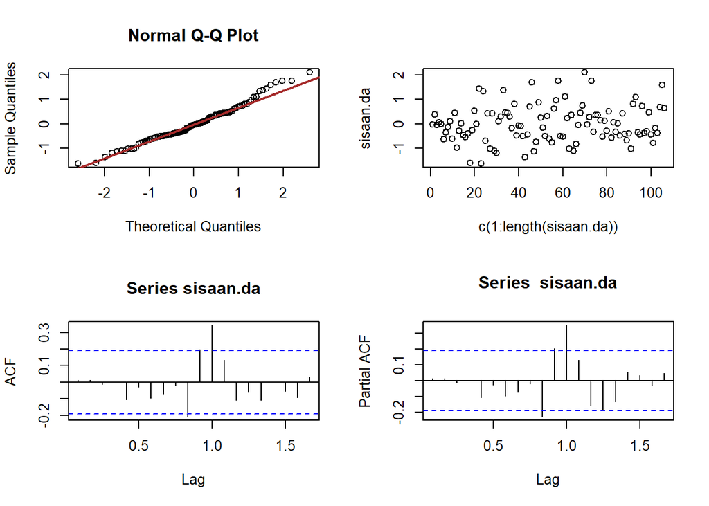

```r
#Eksplorasi
sisaan.da <- model3$residuals
par(mfrow=c(2,2))
qqnorm(sisaan.da)
qqline(sisaan.da, col = "brown", lwd = 2)
plot(c(1:length(sisaan.da)),sisaan.da)
acf(sisaan.da)
pacf(sisaan.da)
```

```r
par(mfrow = c(1,1))
```

### Uji Formal

```r
#1) Sisaan Menyebar Normal
ks.test(sisaan.da,"pnorm")
```

```
##
##  Asymptotic one-sample Kolmogorov-Smirnov test
##
## data:  sisaan.da
## D = 0.11291, p-value = 0.134
## alternative hypothesis: two-sided
```

$H_0$ : Sisaan menyebar normal

$H_1$ : Sisaan tidak menyebar normal

Berdasarkan uji KS tersebut, didapat *p-value* sebesar 0.134 yang lebih dari taraf nyata 5% sehingga tak tolak $H_0$ dan menandakan bahwa sisaan menyebar normal. Hal ini sesuai dengan hasil eksplorasi menggunakan plot kuantil-kuantil normal.

```r
#2) Sisaan saling bebas/tidak ada autokorelasi
Box.test(sisaan.da, type = "Ljung")
```

```
##
##  Box-Ljung test
##
## data:  sisaan.da
## X-squared = 0.017592, df = 1, p-value = 0.8945
```

$H_0$ : Sisaan saling bebas

$H_1$ : Sisaan tidak tidak saling bebas

Berdasarkan uji Ljung-Box tersebut, didapat *p-value* sebesar 0.8945 yang lebih besar dari taraf nyata 5% sehingga tak tolak $H_0$ dan menandakan bahwa sisaan saling bebas. Artinya tidak ada autokorelasi

```r
#3) Sisaan homogen
Box.test((sisaan.da)^2, type = "Ljung")
```

```
##
##  Box-Ljung test
##
## data:  (sisaan.da)^2
## X-squared = 0.34128, df = 1, p-value = 0.5591
```

$H_0$ : Ragam sisaan homogen

$H_1$ : Ragam sisaan tidak homogen

Berdasarkan uji Ljung-Box tersebut. didapat *p-value* sebesar 0.5591 yang lebih besar dari taraf nyata 5% sehingga tak tolak $H_0$ dan menandakan bahwa ragam sisaan homogen

```r
#4) Nilai tengah sisaan sama dengan nol
t.test(sisaan.da, mu = 0, conf.level = 0.95)  #tak tolak h0 > nilai tengah sisaan sama dengan 0
```

```
##
##  One Sample t-test
##
## data:  sisaan.da
## t = 0.023048, df = 105, p-value = 0.9817
## alternative hypothesis: true mean is not equal to 0
## 95 percent confidence interval:
##  -0.1421868  0.1455312
## sample estimates:
##   mean of x
## 0.001672213
```

$H_0$ : nilai tengah sisaan sama dengan 0

$H_1$ : nilai tengah sisaan tidak sama dengan 0

Berdasarkan uji-ttersebut, didapat *p-value* sebesar 0.9817 yang lebih besar dari taraf nyata 5% sehingga tak tolak $H_0$ dan menandakan bahwa nilai tengah sisaan sama dengan 0

# Overfitting

### ARIMA(3,0,3)

```r
model5=Arima(dtkukd.latih.ts, order=c(3,0,3),method="ML")
summary(model5) #AIC=255.61
```

```
## Series: dtkukd.latih.ts
## ARIMA(3,0,3) with non-zero mean
##
## Coefficients:
##          ar1     ar2      ar3     ma1     ma2     ma3     mean
##       0.1894  0.0243  -0.4100  0.9161  0.4380  0.1686  26.1648
## s.e.  0.5131  0.4215   0.2949  0.5171  0.2681  0.2222   0.1522
##
## sigma^2 = 0.5911:  log likelihood = -119.81
## AIC=255.61   AICc=257.09   BIC=276.92
##
## Training set error measures:
##                       ME      RMSE       MAE         MPE     MAPE      MASE
## Training set 0.001762332 0.7429895 0.5849268 -0.07224113 2.220368 0.6870313
##                   ACF1
## Training set 0.0167633
```

```r
lmtest::coeftest(model5)
```

```
##
## z test of coefficients:
##
##            Estimate Std. Error  z value Pr(>|z|)
## ar1        0.189386   0.513144   0.3691  0.71208
## ar2        0.024337   0.421482   0.0577  0.95396
## ar3       -0.410029   0.294882  -1.3905  0.16438
## ma1        0.916088   0.517147   1.7714  0.07649 .
## ma2        0.438033   0.268084   1.6339  0.10227
## ma3        0.168574   0.222160   0.7588  0.44798
## intercept 26.164753   0.152223 171.8843  < 2e-16 ***
## ---
## Signif. codes:  0 '***' 0.001 '**' 0.01 '*' 0.05 '.' 0.1 ' ' 1
```

### ARIMA(4,0,2)

```r
model5=Arima(dtkukd.latih.ts, order=c(4,0,2),method="ML")
summary(model5) #AIC=255.4
```

```
## Series: dtkukd.latih.ts
## ARIMA(4,0,2) with non-zero mean
##
## Coefficients:
##          ar1      ar2      ar3     ar4     ma1     ma2     mean
##       0.9859  -0.5956  -0.0637  0.1035  0.1229  0.1892  26.1694
## s.e.  1.1040   1.6653   1.2502  0.3627  1.1246  0.4990   0.1659
##
## sigma^2 = 0.5898:  log likelihood = -119.7
## AIC=255.4   AICc=256.88   BIC=276.7
##
## Training set error measures:
##                      ME      RMSE       MAE         MPE     MAPE      MASE
## Training set 0.00146553 0.7421908 0.5851709 -0.07303362 2.220116 0.6873181
##                    ACF1
## Training set 0.01307699
```

```r
lmtest::coeftest(model5)
```

```
##
## z test of coefficients:
##
##            Estimate Std. Error  z value Pr(>|z|)
## ar1        0.985947   1.104006   0.8931   0.3718
## ar2       -0.595573   1.665305  -0.3576   0.7206
## ar3       -0.063719   1.250210  -0.0510   0.9594
## ar4        0.103469   0.362702   0.2853   0.7754
## ma1        0.122937   1.124555   0.1093   0.9129
## ma2        0.189201   0.498974   0.3792   0.7046
## intercept 26.169415   0.165900 157.7422   <2e-16 ***
## ---
## Signif. codes:  0 '***' 0.001 '**' 0.01 '*' 0.05 '.' 0.1 ' ' 1
```

# Peramalan

```r
#---FORECAST---#
ramalan <- forecast::forecast(model3, h = 26)
ramalan
```

```
##        Point Forecast    Lo 80    Hi 80    Lo 95    Hi 95
## Nov  9       28.19621 27.22015 29.17228 26.70345 29.68898
## Dec  9       26.16693 24.71086 27.62300 23.94006 28.39380
## Jan 10       24.97258 23.37544 26.56972 22.52996 27.41520
## Feb 10       25.13568 23.53703 26.73432 22.69076 27.58059
## Mar 10       25.97881 24.31919 27.63843 23.44063 28.51698
## Apr 10       26.61025 24.91539 28.30511 24.01819 29.20231
## May 10       26.65914 24.96393 28.35435 24.06654 29.25174
## Jun 10       26.32994 24.62599 28.03390 23.72396 28.93593
## Jul 10       26.01720 24.30487 27.72952 23.39842 28.63598
## Aug 10       25.94100 24.22810 27.65390 23.32134 28.56066
## Sep 10       26.05919 24.34520 27.77319 23.43787 28.68052
## Oct 10       26.20598 24.49017 27.92178 23.58188 28.83007
## Nov 10       26.26309 24.54699 27.97919 23.63854 28.88765
## Dec 10       26.22604 24.50983 27.94224 23.60133 28.85075
## Jan 11       26.16048 24.44392 27.87705 23.53523 28.78574
## Feb 11       26.12572 24.40905 27.84239 23.50030 28.75114
## Mar 11       26.13428 24.41761 27.85096 23.50886 28.75971
## Apr 11       26.16212 24.44538 27.87886 23.53659 28.78764
## May 11       26.18109 24.46432 27.89786 23.55552 28.80666
## Jun 11       26.18109 24.46432 27.89786 23.55552 28.80666
## Jul 11       26.16993 24.45315 27.88671 23.54435 28.79552
## Aug 11       26.16031 24.44352 27.87709 23.53471 28.78591
## Sep 11       26.15856 24.44178 27.87535 23.53296 28.78416
## Oct 11       26.16272 24.44593 27.87951 23.53712 28.78832
## Nov 11       26.16734 24.45055 27.88413 23.54173 28.79294
## Dec 11       26.16887 24.45208 27.88566 23.54326 28.79447
```

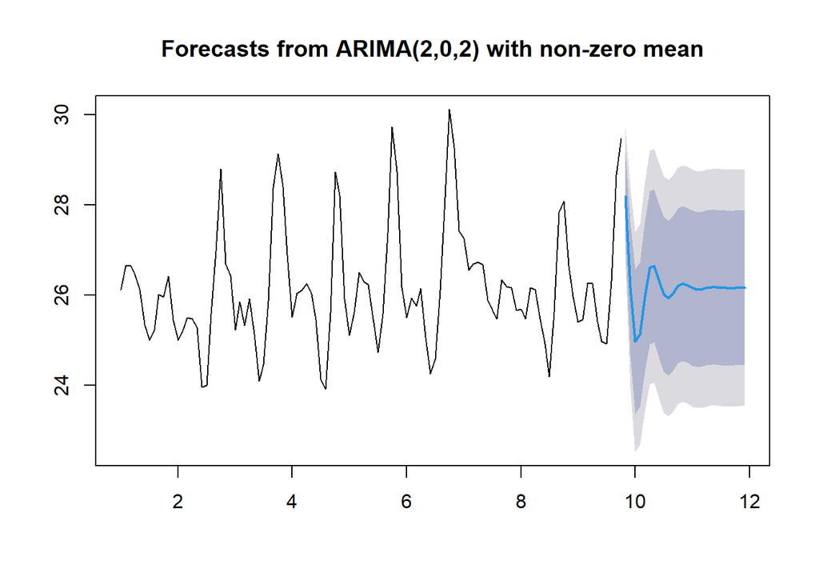

```r
data.ramalan <- ramalan$mean
plot(ramalan)
```

# AKURASI

```r
perbandingan <- matrix(data=c(dtkukd.uji.ts, data.ramalan),
                     nrow = length(dtkukd.uji.ts), ncol = 2)
colnames(perbandingan) <- c("Aktual","Hasil Forecast")
perbandingan
```

```
##       Aktual Hasil Forecast
##  [1,]  28.16       28.19621
##  [2,]  26.18       26.16693
##  [3,]  26.24       24.97258
##  [4,]  26.43       25.13568
##  [5,]  25.93       25.97881
##  [6,]  26.49       26.61025
##  [7,]  25.40       26.65914
##  [8,]  24.31       26.32994
##  [9,]  25.22       26.01720
## [10,]  26.43       25.94100
## [11,]  27.96       26.05919
## [12,]  29.95       26.20598
## [13,]  30.78       26.26309
## [14,]  28.65       26.22604
## [15,]  26.98       26.16048
## [16,]  26.66       26.12572
## [17,]  26.51       26.13428
## [18,]  26.87       26.16212
## [19,]  26.33       26.18109
## [20,]  25.24       26.18109
## [21,]  24.37       26.16993
## [22,]  25.51       26.16031
## [23,]  27.83       26.15856
## [24,]  27.94       26.16272
## [25,]  27.05       26.16734
## [26,]  25.84       26.16887
```

```r
accuracy(data.ramalan[1:26], head(dtkukd.uji.ts,n=length(dtkukd.uji.ts)))
```

```
##                 ME     RMSE      MAE      MPE     MAPE      ACF1 Theil's U
## Test set 0.5602088 1.602384 1.175729 1.816013 4.287897 0.7103501  1.341437
```